# Homework 1

*Ahmet Sualp Say - IE48B - Fall 2021*

```r
options(scipen=999)
```

### Task: Gesture Recognition

Note that there are separate files for each axis and each row corresponds to one gesture in the files. First column has the class information. The information between second and last column is the time ordered observations in the corresponding axis (provided in the file name as X, Y or Z). Moreover, the data is split into training and test sets. For now, you are expected to work with only the training series. Hence, following files are to be used:

• uWaveGestureLibrary_X_TRAIN,

• uWaveGestureLibrary_Y_TRAIN,

• uWaveGestureLibrary_Z_TRAIN

```r
require(data.table)

# assuming you have the XYZ cordinates in your working directory in the following format:
# 'working_directory/'
current_folder = getwd()

file_names = list.files(pattern = "uWaveGestureLibrary")
list_files = lapply(file_names, read.table)

list_files = lapply(seq_along(list_files), function(x) {
  list_files[[x]]$V0 = 1:nrow(list_files[[x]]) # column VO is created to specify the sample instance
  list_files[[x]]
})
```

```r
x <- as.data.table(list_files[1])
y <- as.data.table(list_files[2])
z <- as.data.table(list_files[3])


# melt X cordinates for long format
setnames(x,"V1","class")
setnames(x,"V0","instance")
x = melt(x,id.vars=c('class','instance'))
x[,time:=as.numeric(gsub("\\D", "", variable))-1]
x = x[,list(class,instance, time, value)]
x = x[order(instance, class,time)]
setnames(x, "value", "x_cordinate")


# melt Y cordinates for long format
setnames(y,"V1","class")
setnames(y,"V0","instance")
y = melt(y,id.vars=c('class','instance'))
y[,time:=as.numeric(gsub("\\D", "", variable))-1]
y = y[,list(class,instance, time, value)]
y = y[order(instance, class, time)]
setnames(y, "value", "y_cordinate")

# melt Z cordinates  for long format
setnames(z,"V1","class")
setnames(z,"V0","instance")
z = melt(z,id.vars=c('class','instance'))
z[,time:=as.numeric(gsub("\\D", "", variable))-1]
z = z[,list(class, instance, time, value)]
z = z[order(instance, class, time)]
setnames(z, "value", "z_cordinate")


xy = merge(x,
            y,
            by=c("class","instance","time"))


xyz = merge(xy,
            z,
            by=c("class","instance","time"))
```

```r
# shows x,y,z cordinates of one instance belongs to class 1
head(xyz)
```

| class | instance | time | x_cordinate | y_cordinate | z_cordinate |
| --- | --- | --- | --- | --- | --- |
| 1 | 11 | 1 | -0.7914472 | -1.959984 | -0.2490781 |
| 1 | 11 | 2 | -0.7914472 | -1.959984 | -0.2490781 |
| 1 | 11 | 3 | -0.7958727 | -1.956600 | -0.2514390 |
| 1 | 11 | 4 | -0.8100650 | -1.945750 | -0.2590101 |
| 1 | 11 | 5 | -0.8492300 | -1.915809 | -0.2799033 |
| 1 | 11 | 6 | -0.9034648 | -1.874347 | -0.3088358 |

*1) Read the data and visualize one instance (all axes) from each class and try to relate the shape (time series) you see with the gestures shown in Figure 1. Note that this is an acceleration information. You can transform this information to a velocity vector by computing the cumulative sum of acceleration over time.*

```r
require(lattice)
```

```r
# instances belong to class 1, 2, 3, 4, 5, 6, 7, 8 respectively
samples <- xyz[instance %in% c(11, 15, 4, 5, 2, 1, 7, 6),]
```

```r
velocity_samples = samples[, list(x_cordinate=cumsum(x_cordinate),
                                  y_cordinate=cumsum(y_cordinate),
                                  z_cordinate=cumsum(z_cordinate)), list(class, instance)]
```

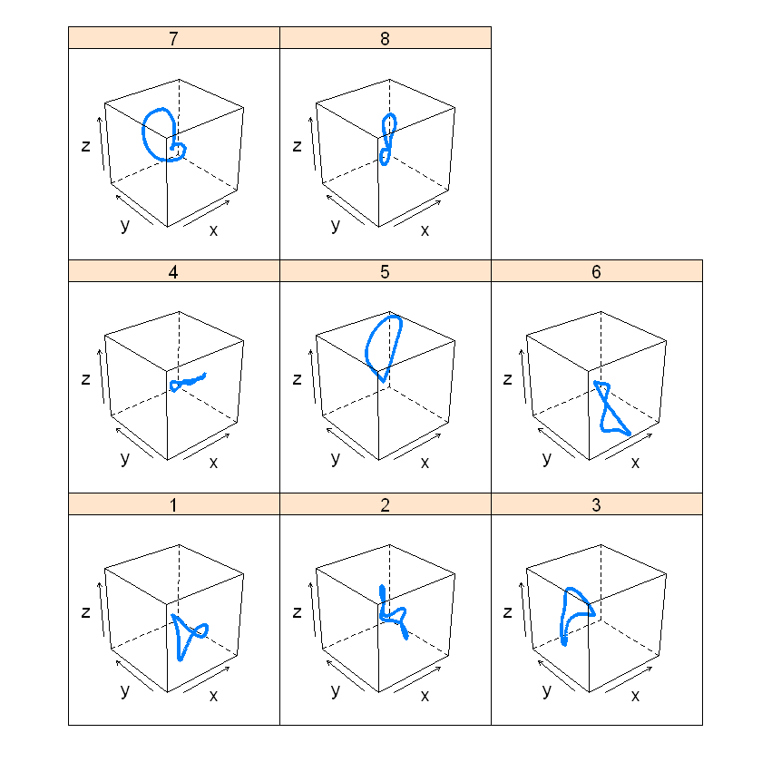

```r
cloud(z_cordinate~x_cordinate*y_cordinate|as.factor(class), data=velocity_samples, xlab="x", ylab="y", zlab="z")
```

*2) Propose two alternative time series representations. In other words, you are expected to summarize the data with few numbers. You can make use of the representations discussed in the class. Alternatively, based on your observations or research, you can propose alternative representations. Evaluate your proposed representation visually (as covered in the examples in the class). Due to this restriction, you may want to end up with simple representations (i.e. 1D or 2D) that are easier to visualize based on the class information. Compare your representations and justify your choice of introduced feature representation.*

```r
require(ggplot2)
require(repr)

options(repr.plot.width=15, repr.plot.height=8)
```

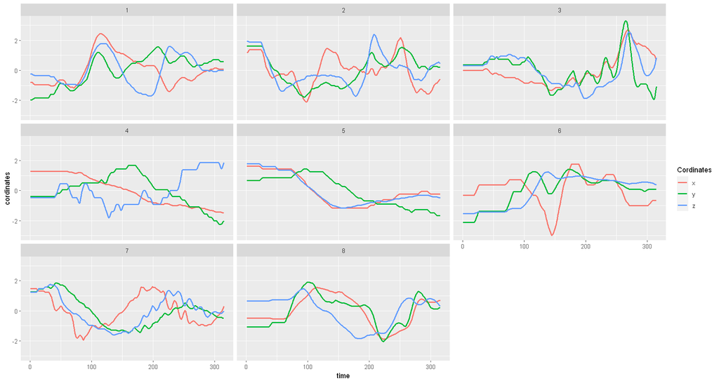

```r
ggplot(samples, aes(time)) +  geom_line(aes(y = x_cordinate,  colour = "x"), size=1) + geom_line(aes(y = y_cordinate, colour = "y"), size=1) +  geom_line(aes(y = z_cordinate, colour = "z"), size=1) + scale_color_discrete(name = "Cordinates") + facet_wrap(~class) + ylab("cordinates")
```

Time series data will be summarised by two methods as follows: *Using Segment Based Stats & Using Model Based Error*

###### Using Segment Based Stats

Series segmented into two same length interval and median calculated for these two interval

```r
xyz[, interval_index:=as.numeric(cut(time, 2, ordered_result=T), list(instance))]
interval_statistic = xyz[, list(x_median=median(x_cordinate), y_median=median(y_cordinate), z_median=median(z_cordinate)), list(class,instance,interval_index)]
head(interval_statistic)
```

| class | instance | interval_index | x_median | y_median | z_median |
| --- | --- | --- | --- | --- | --- |
| 1 | 11 | 1 | -0.63229075 | -0.8837934 | -0.333982730 |
| 1 | 11 | 2 | -0.04457784 | 0.6017778 | 0.005635896 |
| 1 | 17 | 1 | 0.33237473 | -0.5993304 | -0.020365943 |
| 1 | 17 | 2 | -0.68035186 | 0.8135513 | 0.163084690 |
| 1 | 19 | 1 | -0.06226490 | -1.1876442 | -0.810846110 |
| 1 | 19 | 2 | 0.18101856 | 0.5578663 | 0.136456780 |

```r
# represent each series with the interval means
interval_statistic_x = dcast(interval_statistic, instance+class~paste0('interval_',interval_index),value.var='x_median')
interval_statistic_x$statistic <- "x"

interval_statistic_y = dcast(interval_statistic, instance+class~paste0('interval_',interval_index),value.var='y_median')
interval_statistic_y$statistic <- "y"

interval_statistic_z = dcast(interval_statistic, instance+class~paste0('interval_',interval_index),value.var='z_median')
interval_statistic_z$statistic <- "z"

summary = rbind(interval_statistic_x, interval_statistic_y, interval_statistic_z)
summary[, class:=as.factor(class)]
```

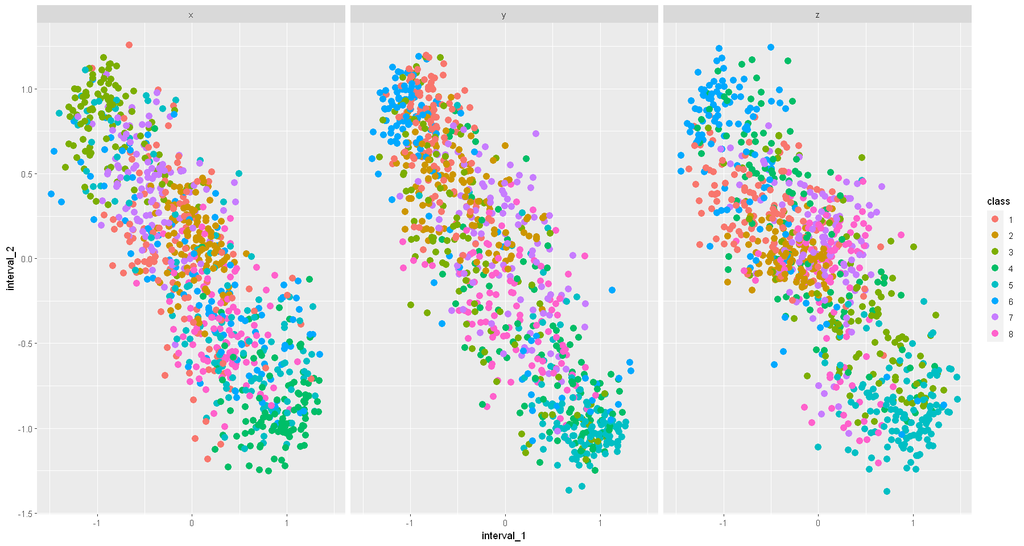

```r
ggplot(summary, aes(x = interval_1, y = interval_2, color = class)) + geom_point(size = 3) + facet_wrap(~statistic)
```

###### Using Model Based Error

Using inputs as x_lag1, x_lag2, y_lag1, y_lag2, z_lag1, z_lag2 and target variable as x_cordinate, an autoregressive model of lag 2 will be fit.

```r
ar_xyz = copy(xyz)
ar_xyz = ar_xyz[order(instance,time)]

ar_xyz[,x_lag1:=shift(x_cordinate,1), list(instance)]
ar_xyz[,x_lag2:=shift(x_cordinate,2), list(instance)]
ar_xyz[,y_lag1:=shift(y_cordinate,1), list(instance)]
ar_xyz[,y_lag2:=shift(y_cordinate,2), list(instance)]
ar_xyz[,z_lag1:=shift(z_cordinate,1), list(instance)]
ar_xyz[,z_lag2:=shift(z_cordinate,2), list(instance)]

fit_ar2 = function(xyz){

    fit = lm(x_cordinate~x_lag1+x_lag2+y_lag1+y_lag2+z_lag1+z_lag2, xyz)
    return(fit)
}

class_type=unique(ar_xyz$class)
fitted_models=lapply(class_type, function(x) fit_ar2(ar_xyz[class==x]))

ar_xyz_residuals = copy(ar_xyz)

for(i in 1:length(class_type)){

    current_class=class_type[i]
    ar_xyz_residuals[,paste0('residual_',current_class):=x_cordinate-predict(fitted_models[[i]], ar_xyz_residuals)]
}
```

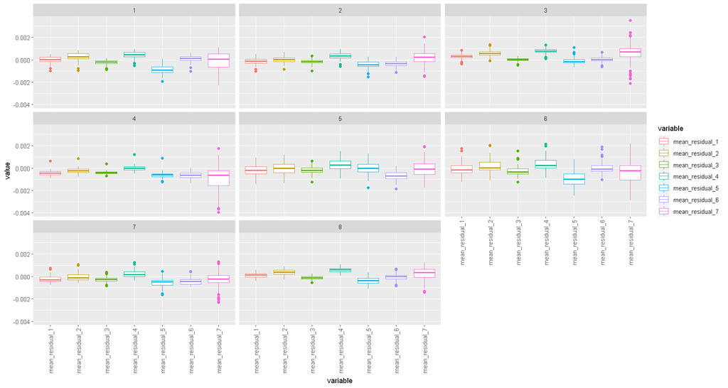

```r
residual_statistics = ar_xyz_residuals[,list(mean_residual_1=mean(residual_1, na.rm=T),
                                             mean_residual_2=mean(residual_2, na.rm=T),
                                             mean_residual_3=mean(residual_3, na.rm=T),
                                             mean_residual_4=mean(residual_4, na.rm=T),
                                             mean_residual_5=mean(residual_5, na.rm=T),
                                             mean_residual_6=mean(residual_6, na.rm=T),
                                             mean_residual_7=mean(residual_7, na.rm=T),
                                             mean_residual_7=mean(residual_8, na.rm=T)), list(instance, class)]

residual_statistics = melt(residual_statistics, id.vars=c('instance','class'))

ggplot(residual_statistics, aes(x=variable, y=value, color=variable)) + geom_boxplot() + facet_wrap(~class) +  theme(axis.text.x = element_text(angle = 90, vjust = 0.5, hjust=1))
```